# Newest Drug Score

Wajd

19 avril 2018

# Business Objectives

L’objectif est de générer un modèle adaptable qui permet de lire une description de produits de n’importe quel thème et détecteur les drogues parmi ces produits.

Cela s’inscrit dans une perspective plus large, au delà de la drogue: Compliance detection.

```r
library(tm)
library(qdap)
library(e1071)
library(ROCR)
```

```r
library(SnowballC)
library(wordcloud)
library(RTextTools)
library(tidytext)
if(sessionInfo()['basePkgs']=="dplyr" | sessionInfo()['otherPkgs']=="dplyr"){
  detach(package:dplyr, unload=TRUE)
}
library(plyr); library(dplyr)
library(arules)
library(SnowballC)
library(class)
library(wordcloud)
library(igraph)
library(RWeka)
library(slam)
library(NLP)
library(caret)
```

# Fonctions personnalisées

Clean normalize récupère une chaîne de caractères et la prépare pour le modèle.

```r
column_to_remove=read.csv(file="colnames.csv")
column_to_remove<-column_to_remove$x

clean_normalize <- function(drug_string){
  stemmed_drug_string<-stemmer(drug_string, warn=F)
  stemmed_drug_string<-tolower(stemmed_drug_string)
  stemmed_drug_string<- stemmed_drug_string[stemmed_drug_string %in% AllPredictors]
  stemmed_drug_string<-paste(stemmed_drug_string,collapse=" ")
  DirtyDescriptions_test_final_source <- VectorSource(stemmed_drug_string)
  DirtyDescriptions_test_final_corpus <- VCorpus(DirtyDescriptions_test_final_source)
  cleandrugs_test_final_corp <- clean_corpus(DirtyDescriptions_test_final_corpus)
  cleandrug_test_final_dtm <- DocumentTermMatrix(DirtyDescriptions_test_final_corpus,
                                                 control =
                                                   list(removePunctuation=TRUE,
                                                        stopwords=TRUE
                                                        ))
  X_test_final <- as.matrix(cleandrug_test_final_dtm)
  normalized_mean<-(sum(X_test_final)-mean(trainRowSums))/sd(trainRowSums)
  normalized<-(sum(X_test_final)-min(trainRowSums))/(max(trainRowSums)-min(trainRowSums))
  return(min(sum(X_test_final), max(trainRowSums)));
}
```

Clean_corpus récupère un corpus de tets et le nettoie.

```r
clean_corpus <- function(corpus){
  corpus <- tm_map(corpus, content_transformer(tolower))

  toSpace <- content_transformer(function(x, pattern) gsub(pattern, "", x))
  corpus <- tm_map(corpus, toSpace, "[^a-zA-Z ]")
  corpus <- tm_map(corpus, toSpace, "â")
  corpus <- tm_map(corpus, toSpace, "ª")
  corpus <- tm_map(corpus, toSpace, "œ")
  corpus <- tm_map(corpus, toSpace, "¤")

  #weird="âœªâ¤âœªâ¤âœªâ¤âœªâ¤âœªâ¤âœªâ¤âœªâ¤âœªâ¤âœªâ¤âœªâ¤âœªâ¤âœª"
  #Remove profane words
  #First get the list of bad words
  #bwdat<-read.table("en_bws.txt", header=FALSE, sep="\n", strip.white=TRUE)
  # names(bwdat)<-"Bad Words"
  #  corpus<- tm_map(corpus, removeWords, bwdat[,1])

  corpus <- tm_map(corpus, stripWhitespace)
  corpus <- tm_map(corpus, removeWords, c("the","day","yes","yet", "like","œ","¤","â","will", "sale","get", "good","also","best","can",  "and", stopwords("english") ))
  corpus <- tm_map(corpus, removeNumbers)
  corpus <- tm_map(corpus, removePunctuation)

  corpus <- tm_map(corpus, stemDocument, language = "english")
  corpus <- tm_map(corpus, removeWords, c("dri","line","busi","die","extrem","china","oil","Durban","green","classic","citrus","crush","cheap","old","oral","trust","user","use","mtehod","suppli","lemon","extra","usp","vacuum","trim","straight","satisfact","usd","Dri","Green","Addit","youll","your","collect","huge","flipkartcom","price","order","list","onlin","pleas","ship","buy","com","flipkart","aaa","deliveri","cash","one","india","shop","read","set","print","new","page","come","requir","give","name","know","item","general","red","question","add","final","take","want","see","around","discount","content","two"))

  corpus <- tm_map(corpus, removeWords, c("addit", "amnesia", "aroma", "bar",
                                          "batch","display", "black", "blister", "blueberri", "buzz","blend","crystal", "contact","chemic", "chine", "clean", "clear", "cure","dark", "drop", "durban", "dutch", "experi", "experienc", "express", "flavor", "flower", "flush", "fresh", "grow", "grower", "grown", "hard", "hit", "hybrid", "ice", "ingredi","instant", "legendari","light", "limit", "liquid", "local", "love", "magic", "medic", "medicin", "method", "natur","nice", "northern", "organ", "ounc", "potenc", "power", "rare", "rate","relax", "safe", "sampl", "sleep", "smell", "soft","strength", "stronger", "stuff", "supplier", "synthet", "thing", "treatment","wax", "white"))
  corpus <- tm_map(corpus, removeWords, column_to_remove)

  return(corpus)
}
```

# Récupération et préparation des données

On a deux fichiers contenant des textes concernant la drogue, category et description. Le site d’où on a récupéré les données contient tant des drogues que des autres contenus illégaux. On va utiliser category pour filtrer

```r
AllDrugsCategory <- read.table("Category_New.csv", header=T,fill=T, encoding="utf-8", sep="\n", dec=".",quote = "", na.string="" )
AllDrugsDescriptions <- read.table("Description_New.csv",stringsAsFactors = FALSE, header=T,fill=T, encoding="utf-8", sep="²", dec=".",quote = "", na.string="" )

AllDrugsDescriptions<-AllDrugsDescriptions[1:109690,]
AllDrugsDescriptions<-AllDrugsDescriptions$Item.Description.sep
AllDrugsCategory<-AllDrugsCategory$Category

AllDrugs<-data.frame(AllDrugsDescriptions, AllDrugsCategory)
names(AllDrugs)=c("Description", "Category")
AllDrugs$Description=as.character(AllDrugs$Description)


AllDrugs=AllDrugs[which(substr(AllDrugs$Category,1,6)=="Drugs/"),]

AllDrugs=AllDrugs[which(nchar (AllDrugs$Description)>200),]

Drugs=AllDrugs$Description
Drugs=as.character(Drugs)

IllegalVector<- vector(mode="logical", length=length(Drugs))
IllegalVector=rep(TRUE,length(Drugs))

MyData=data.frame(Drugs,IllegalVector)
names(MyData)=c("Description", "Legality")

DirtyDescriptions=MyData$Description
```

On crée ensuite une document term matrix contenant chaque ligne de nos descriptions dans les lignes et chaque mot unique dans les colonnes

```r
#I need a corpus
DirtyDescriptions_source <- VectorSource(DirtyDescriptions)
DirtyDescriptions_corpus <- VCorpus(DirtyDescriptions_source)
#A clean corpus
cleandrugs_corp <- clean_corpus(DirtyDescriptions_corpus)
#Document Term Matrix, because we need to be organized folk
cleandrug_dtm <- DocumentTermMatrix(cleandrugs_corp)
#I hate useless words
cleandrug_dtm <- removeSparseTerms(cleandrug_dtm, 0.995)

target=MyData$Legality
X <- as.matrix(cleandrug_dtm)
X<-as.data.frame(X)

y<-target
```

```r
data <- as.data.frame(cbind(y,X))
colnames(data[2:length(colnames(data))])
```

```
##   [1] "adderal"       "afford"        "afghan"        "afghani"
##   [5] "alprazolam"    "amphetamin"    "anabol"        "anxieti"
##   [9] "benzo"         "benzodiazepin" "bho"           "bitcoin"
##  [13] "blotter"       "book"          "btc"           "bubba"
##  [17] "bud"           "butan"         "cannabi"       "capsul"
##  [21] "cerebr"        "chemist"       "cocain"        "coke"
##  [25] "concentr"      "cook"          "cooki"         "crack"
##  [29] "cubensi"       "dank"          "darknet"       "diazepam"
##  [33] "diesel"        "dmt"           "doesnt"        "dosag"
##  [37] "dose"          "drug"          "ecstasi"       "escrow"
##  [41] "euphor"        "euphoria"      "extract"       "fentanyl"
##  [45] "fishscal"      "grade"         "gram"          "greenhous"
##  [49] "guid"          "harvest"       "hash"          "haze"
##  [53] "hcl"           "heroin"        "hindu"         "holland"
##  [57] "imprint"       "indica"        "inject"        "ketamin"
##  [61] "kush"          "lab"           "labtest"       "lsd"
##  [65] "marijuana"     "mdma"          "medicalgrad"   "medium"
##  [69] "meth"          "muscl"         "mushroom"      "netherland"
##  [73] "oxycodon"      "oxycontin"     "pgp"           "pharmaceut"
##  [77] "pharmaci"      "poison"        "potent"        "powder"
##  [81] "psilocyb"      "psychedel"     "pungent"       "pure"
##  [85] "purest"        "puriti"        "reagent"       "sativa"
##  [89] "sativadomin"   "seed"          "shit"          "smoke"
##  [93] "snort"         "stealth"       "steroid"       "stimul"
##  [97] "stone"         "strain"        "strongest"     "substanc"
## [101] "tablet"        "testosteron"   "thc"           "trip"
## [105] "uncut"         "valium"        "viagra"        "vial"
## [109] "weed"          "xanax"         "xtc"
```

```r
trainPositive<-data[rowSums(data[2:length(colnames(data))]) != 0,]
NaturalPredictors=setdiff(colnames(trainPositive), c("y"))
inTrain<-createDataPartition(1:nrow(trainPositive),p=0.8,list=FALSE)
trainpredictors<-trainPositive[inTrain,NaturalPredictors]
trainLabels<-trainPositive[inTrain,"y"]
table(trainLabels)
```

```
## trainLabels
##  TRUE
## 22772
```

Notre modèle récupère des rowsums en guise de score: plus le score est élevé et plus la donnée a de chance d’être de la drogue. Nous allons donc nous débarrasser des drogues avec les scores les plus faibles pour aiguiser notre modèle.

```r
trainRowSums=rowSums(trainpredictors[rowSums(trainpredictors) > quantile(rowSums(trainpredictors), 0.1),])
trainTarget=trainLabels[rowSums(trainpredictors) > quantile(rowSums(trainpredictors), 0.1)]
```

# Récupération des données légales

On va utiliser des données provenant de flipkart, un site indien vendant tout et n’importe quoi, comme base pour notre testing set.

On a aussi récupéré un jeu de données issu de la DEA, Drug Enforcement Agency, qu’on a préparé à l’avance et qui formera la base de nos colonnes.

```r
SampleDrugs <- read.table("flipkart.csv", header=T,fill=T, encoding="utf-8", sep="\n", dec=".",quote = "", na.string="" )
names(SampleDrugs)=c("Description")
SampleDrugs$Description=as.character(SampleDrugs$Description)
SampleDrugs=SampleDrugs[which(nchar (SampleDrugs$Description)>180),]
#SampleDrugs=stemmer(SampleDrugs)
SampleDrugs=lapply(SampleDrugs, FUN=stemmer,warn=F)

DEAPredictors=read.csv(file="Refined_Drug_Slangs.txt")
AllPredictors=c(as.character(DEAPredictors$x), NaturalPredictors)

SampleDrugs=lapply(SampleDrugs, function(x) {
  x <- unlist(strsplit(x, " "))
  x <- x[tolower(x) %in% AllPredictors]
  x<-paste(x,collapse=" ")
})
```

On prépare ensuite les données de test dans un document term matrix

```r
DirtyDescriptions_test_source <- VectorSource(SampleDrugs)
DirtyDescriptions_test_corpus <- VCorpus(DirtyDescriptions_test_source)
cleandrugs_test_corp <- clean_corpus(DirtyDescriptions_test_corpus)

#Document Term Matrix, because we need to be organized folk
cleandrug_test_dtm <- DocumentTermMatrix(cleandrugs_test_corp)

X_test <- as.matrix(cleandrug_test_dtm)
```

On va préparer une matrice contenant les termes en colonnes et les documents en lignes. On va se débarrasser de toutes les colonnes qui ne représentent aucun intérêt pour nous

```r
Legality_Test<- vector(mode="logical", length=length(SampleDrugs))
Legality_Test=rep(FALSE,length(SampleDrugs))

y_test<-Legality_Test

Negative_Test <- as.data.frame(cbind(y_test,X_test))
Negative_Test$y_test<-as.logical(Negative_Test$y_test)
mat <- matrix(rep(0,nrow(Negative_Test)*length(NaturalPredictors)), nrow = nrow(Negative_Test), ncol =length(NaturalPredictors))
colnames(mat)=NaturalPredictors
mat<-as.data.frame(mat)

columns_to_delete=colnames(as.data.frame(Negative_Test))

trainRowSums<-c(rep(1,2000),rep(1.1,2000),trainRowSums)
trainTarget<-c(rep(TRUE,4000),trainTarget)

mat<-mat[ , !(names(mat) %in% columns_to_delete)]
colnames(mat)
```

```
##  [1] "adderal"       "afghan"        "afghani"       "alprazolam"
##  [5] "amphetamin"    "anabol"        "benzo"         "benzodiazepin"
##  [9] "bho"           "bitcoin"       "blotter"       "btc"
## [13] "bubba"         "butan"         "cannabi"       "cerebr"
## [17] "chemist"       "cocain"        "coke"          "cooki"
## [21] "cubensi"       "dank"          "darknet"       "diazepam"
## [25] "diesel"        "dmt"           "dosag"         "drug"
## [29] "escrow"        "euphor"        "euphoria"      "fentanyl"
## [33] "fishscal"      "greenhous"     "hash"          "haze"
## [37] "hcl"           "heroin"        "holland"       "ketamin"
## [41] "labtest"       "lsd"           "marijuana"     "mdma"
## [45] "medicalgrad"   "meth"          "netherland"    "oxycodon"
## [49] "oxycontin"     "pgp"           "pharmaceut"    "pharmaci"
## [53] "poison"        "potent"        "psilocyb"      "psychedel"
## [57] "pungent"       "reagent"       "sativa"        "sativadomin"
## [61] "shit"          "snort"         "stealth"       "steroid"
## [65] "strongest"     "testosteron"   "thc"           "uncut"
## [69] "valium"        "viagra"        "vial"          "xanax"
## [73] "xtc"
```

```r
data_test<- as.data.frame(cbind(Negative_Test,mat))
data_test<-data_test[ , (names(data_test) %in% c(NaturalPredictors,"y_test"))]
dim(data_test)
```

```
## [1] 19962   112
```

```r
colnames(data_test)[1] <- "y"

testPositive<-trainPositive[-inTrain,]
testnegative<-data_test

testPosNeg<-rbind(testPositive,testnegative)
testLabels<-testPosNeg[,"y"]
table(testLabels)
```

```
## testLabels
## FALSE  TRUE
## 19962  5692
```

```r
testpredictors<-testPosNeg[,NaturalPredictors]
```

On va essayer de faire tune svm pour trouver les paramètres idéaux grâce au k fold cross validation

```r
tuned <- tune.svm(x=trainRowSums, y=trainTarget,
                  nu =  0.001:0.5,
                  gamma = 10^(-2:0),
                  type='one-classification'
);
tuned
svm.model<-svm(trainRowSums,y=NULL, type='one-classification', nu=0.001,gamma=0.01, scale=TRUE, kernel="radial")
#save(svm.model, file = "svm.model.RData")
```

[output not shown]

On va à présent utiliser le modèle pour prédire tant le testing set et le training set.

```r
svm.predtrain<-predict(svm.model,trainRowSums)
svm.predtest<-predict(svm.model,rowSums(testpredictors))

confTrain<-table(Predicted=svm.predtrain,Reference=trainTarget)
confTest<-table(Predicted=svm.predtest,Reference=testLabels)

print(confTrain)
```

```
##          Reference
## Predicted  TRUE
##     FALSE     2
##     TRUE  20809
```

```r
print(confTest)
```

```
##          Reference
## Predicted FALSE  TRUE
##     FALSE 18549     0
##     TRUE   1413  5692
```

```r
accuracy=sum(diag(confTest))/sum(confTest)
precision=confTest[4]/(confTest[4]+confTest[2])
recall=confTest[4]/(confTest[4]+confTest[3])
F1_Score=2*(precision*recall)/(recall+precision)
```

```
## [1] "Accuracy:"
```

```
## [1] 0.9449209
```

[output not shown]

[output not shown]

[output not shown]

Les résultats nous semblent assez acceptables. Voyons voir la courbe ROC

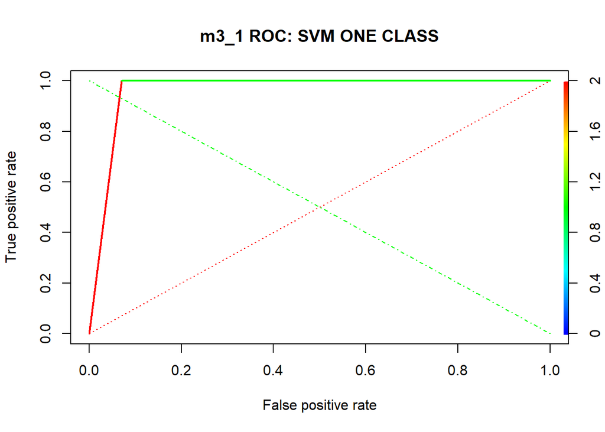

```r
m3_1_pred <- prediction( as.numeric(svm.predtest) , as.numeric(testLabels))
m3_1_perf <- performance(m3_1_pred, "tpr", "fpr")

plot(m3_1_perf,colorize=TRUE, lwd=2, main = "m3_1 ROC: SVM ONE CLASS", col = "blue")
lines(x=c(0, 1), y=c(0, 1), col="red", lwd=1, lty=3);
lines(x=c(1, 0), y=c(0, 1), col="green", lwd=1, lty=4)
```

La courbe montre un résultat acceptable

# Test avec des données rentrées manuellement

On va nous intéresser à deux types d’extrêmes pour voir l’adaptabilité de notre modèle. Une phrase longue contenant beaucoup de termes de la drogue. Une phrase courte contenant tout juste un seul terme. Une phrase longue légale et une phrase courte contenant un seul mot légal.

```r
drug_string="I'm selling some pretty sweet zacateca
if you're interested call me it's gonna be xtreme, got some weird seed, oxycontin
potent and pure heroin, good kush coming straight from holland man"
drug_string_2="zacateca"
non_drug_string_1="I want to sell some food pizza chawarma love  cream"
non_drug_string_2="Potato?"

svm.predtrain_1<-predict(svm.model,clean_normalize(drug_string))
svm.predtrain_2<-predict(svm.model,clean_normalize(drug_string_2))
svm.predtrain_3<-predict(svm.model,clean_normalize(non_drug_string_1))
svm.predtrain_4<-predict(svm.model,clean_normalize(non_drug_string_2))
```

On va passer à la prédiction

```
## [1] "IS THIS A DRUG?"
```

```
## [1] "Correct: TRUE"
```

```
## [1] "Predicted: "
```

```
##    1
## TRUE
```

```
## [1] "Correct: TRUE"
```

```
## [1] "Predicted: "
```

```
##    1
## TRUE
```

```
## [1] "Correct: FALSE"
```

```
## [1] "Predicted: "
```

```
##     1
## FALSE
```

```
## [1] "Correct: FALSE"
```

```
## [1] "Predicted: "
```

```
##     1
## FALSE
```

Comme vous le voyez, les résultats semblent acceptables